# Using thermodynamics to obtain geochemical information from genomes (2023)

This vignette runs the code to make the plots from the following paper:

> Dick JM, Boyer GM, Canovas PA III, Shock EL. 2023. Using thermodynamics to obtain geochemical information from genomes. *Geobiology* **21**(2): 262–273 doi: 10.1111/gbi.12532

[Click here](https://onlinelibrary.wiley.com/share/author/Q9GIUWDD4K8NQ4IDJK4C?target=10.1111/gbi.12532) for full-text access to a view-only version of the paper.

On 2024-01-09, Figure 4 was modified from the original publication to show *percentages* of average affinity rankings of groups. This does not change the crossover points of the lines (on the *x* axis), but does make the absolute positions of the lines (on the *y* axis) not depend on the number of genomes in each group.

This vignette was compiled on 2025-05-20 with **JMDplots** 1.2.22 and **[CHNOSZ](http://chnosz.net)** 2.1.0-72.

```r
library(JMDplots)
```

## Chemical analysis of reference proteomes of methanogens reveals adaptation to redox conditions (Figure 1)

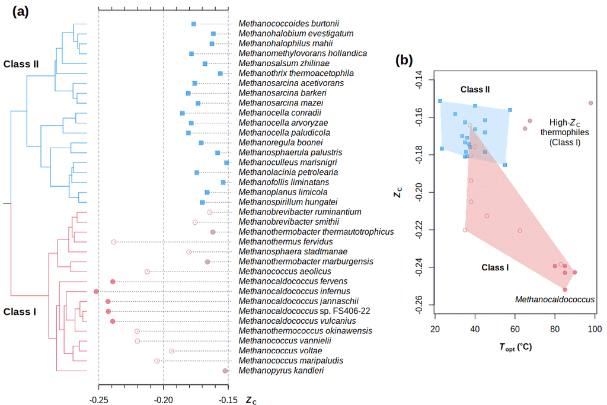

```r
utogig1()
```

**Data sources:** Hierarchical clustering tree of methanogenesis genes (Lyu and Lu, 2018); *Z*<sub>C</sub> calculated for reference proteomes (Dick and Tan, 2023) based on RefSeq protein sequences (O’Leary et al., 2016). See Table S1 in the paper’s Supplementary Information for references for optimal growth temperature (*T*<sub>opt</sub>).

## Relative stabilities of organic compounds depend on redox conditions (Figure 2)

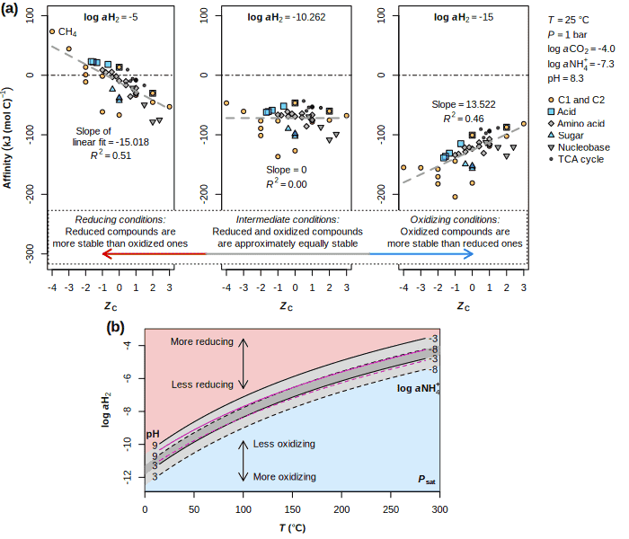

```
## [1] "p-values for (a):"
## [1] 1.1e-08 1.0e+00 1.2e-07
```

```r
utogig2()
```

**Data sources:** List of organic compounds from Shock and Canovas (2010) and TCA cycle metabolites from Canovas and Shock (2016). See Table 1 in the paper for references for thermodynamic data.

## Thermodynamic model for methanogen niche structure (Figure 3)

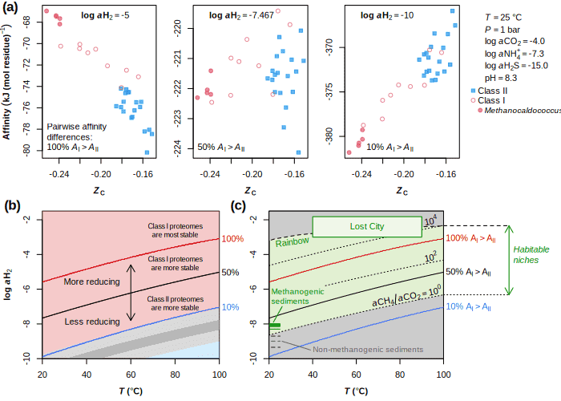

```r
utogig3()
```

**Data sources:** Lost City *T* and H<sub>2</sub> concentration (Kelley et al., 2005), Rainbow vent fluid mixing model (Shock and Canovas, 2010), methanogenic and non-methanogenic sediments (Lovley and Goodwin, 1988).

## Chemical and thermodynamic analysis of evolutionary divergence along redox gradients (Figure 4)

```r
Table_S6 <- utogig4()
```

[figure not shown]

[output not shown]

**Data sources:** Methanogens (Lyu and Lu, 2018), Nif-bearing organisms (Poudel et al., 2018), Thaumarchaeota (Ren et al., 2019). Amino acid compositions are from RefSeq proteomes (methanogens and Nif-bearing organisms) or NCBI and IMG genomes (Thaumarchaeota).

## Parametric and non-parametric tests of comparisons in Figure 4 (Table S6)

- **p_Tukey**: One-way ANOVA followed by Tukey’s Honest Significant Difference test.
- **p_Dunn**: Kruskal-Wallis test followed by Dunn’s test with Bonferroni correction for multiple comparisons.

```r
kable(Table_S6, row.names = FALSE, digits = 99, format.args = list(scientific = TRUE))
```

| Variable | Comparison | p_Tukey | p_Dunn |
| --- | --- | --- | --- |
| Methanogens Zc | Class I - Class II | 7.6e-05 | 3.0e-03 |
| Nif-encoding Zc | NifA - NifB | 1.9e-12 | 7.6e-11 |
| Nif-encoding Zc | NifA - NifC | 0.0e+00 | 3.7e-10 |
| Nif-encoding Zc | NifA - NifD | 3.1e-04 | 6.8e-03 |
| Nif-encoding Zc | NifB - NifC | 5.6e-09 | 3.8e-02 |
| Nif-encoding Zc | NifB - NifD | 5.8e-01 | 1.0e+00 |
| Nif-encoding Zc | NifC - NifD | 3.1e-02 | 1.0e+00 |
| Thaumarchaeota Zc | Basal - Deep | 6.2e-01 | 1.0e+00 |
| Thaumarchaeota Zc | Basal - Shallow | 7.3e-02 | 1.3e-01 |
| Thaumarchaeota Zc | Basal - Terrestrial | 2.4e-03 | 1.8e-03 |
| Thaumarchaeota Zc | Deep - Shallow | 6.2e-01 | 5.7e-01 |
| Thaumarchaeota Zc | Deep - Terrestrial | 7.7e-02 | 1.6e-02 |
| Thaumarchaeota Zc | Shallow - Terrestrial | 5.7e-01 | 9.6e-01 |
| Thaumarchaeota nH2O | Basal - Deep | 1.7e-01 | 1.4e-01 |
| Thaumarchaeota nH2O | Basal - Shallow | 8.8e-01 | 1.0e+00 |
| Thaumarchaeota nH2O | Basal - Terrestrial | 3.5e-01 | 1.0e+00 |
| Thaumarchaeota nH2O | Deep - Shallow | 2.1e-02 | 2.4e-02 |
| Thaumarchaeota nH2O | Deep - Terrestrial | 1.2e-03 | 1.4e-03 |
| Thaumarchaeota nH2O | Shallow - Terrestrial | 7.6e-01 | 1.0e+00 |

## Comparison of *Z*<sub>C</sub> of proteomes predicted by Glimmer and downloaded from NCBI (Figure S1)

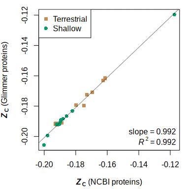

```r
utogigS1()
```

## Association between redox gradients and *Z*<sub>C</sub> of proteins and lipids in alkaline Yellowstone hot springs (Figure S2)

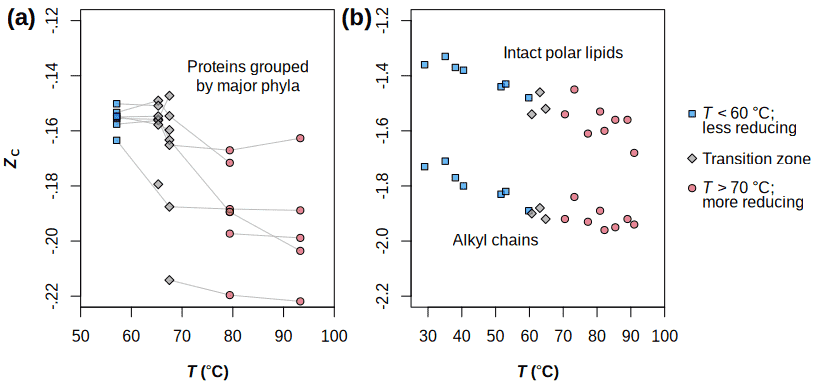

```r
utogigS2()
```

**Data sources:** Proteins (Dick and Shock, 2013) and lipids (Boyer et al., 2020).

## Relative stabilities of organic compounds at lower activity (Figure S3)

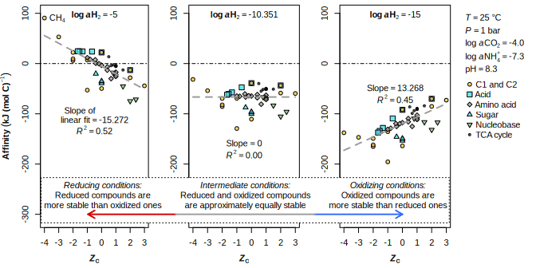

```
## [1] "p-values:"
## [1] 6.0e-09 1.0e+00 1.5e-07
```

```r
utogig2(logact = -6)
```

## log *a*H<sub>2</sub>-*T* plots for different organic compound classes (Figure S4)

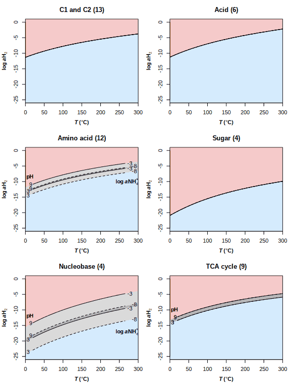

```r
utogigS4()
```

## Convert log *a*H<sub>2</sub> to Eh

```r
logaH2_15 <- -15
pH <- 7
(logK1 <- subcrt(c("H2", "H+", "e-"), c(-1, 2, 2), T = 25)$out$logK)
```

```
## [1] 3.105009
```

```r
pe <- (- logK1 - 2 * pH - logaH2_15) / 2
Eh <- convert(pe, "Eh")
print(paste0("Given logaH2 = ", logaH2_15, " and pH = ", pH, ", Eh = ", round(1000 * Eh), " mV at equilibrium"))
```

```
## [1] "Given logaH2 = -15 and pH = 7, Eh = -62 mV at equilibrium"
```

## Convert *p*<sub>H<sub>2</sub></sub> to log *a*H<sub>2</sub>

```r
(logK2 <- subcrt(c("H2", "hydrogen"), c(-1, 1), T = 25)$out$logK)
```

```
## [1] 3.105009
```

```r
# pH2 = 10^-2
logpH2 <- -2
print(paste0("Given logpH2 = ", logpH2, ", logaH2 = ", round(logpH2 - logK2, 1), " at equilibrium"))
```

```
## [1] "Given logpH2 = -2, logaH2 = -5.1 at equilibrium"
```

```r
# 0.55 ppmv H2
logpH2 <- log10(0.55e-6)
print(paste0("Given logpH2 = ", round(logpH2, 2), ", logaH2 = ", round(logpH2 - logK2, 1), " at equilibrium"))
```

```
## [1] "Given logpH2 = -6.26, logaH2 = -9.4 at equilibrium"
```

## Convert log *a*H<sub>2</sub> to log *f*H<sub>2</sub> and log *f*O<sub>2</sub>

```r
(logK3 <- subcrt(c("H2O", "oxygen", "hydrogen"), c(-1, 0.5, 1), T = 25)$out$logK)
```

```
## [1] -41.55238
```

```r
logfH2 <- logaH2_15 + logK2
logfO2 <- 2 * (logK3 - logfH2)
print(paste0("Given logaH2 = ", logaH2_15, ", logfH2 = ", round(logfH2, 1), " at equilibrium"))
```

```
## [1] "Given logaH2 = -15, logfH2 = -11.9 at equilibrium"
```

```r
print(paste0("Given logaH2 = ", logaH2_15, ", logfO2 = ", round(logfO2, 1), " at equilibrium"))
```

```
## [1] "Given logaH2 = -15, logfO2 = -59.3 at equilibrium"
```

## References

Boyer GM, Schubotz F, Summons RE, Woods J, Shock EL. 2020. Carbon oxidation state in microbial polar lipids suggests adaptation to hot spring temperature and redox gradients. *Frontiers in Microbiology* **11**: 229. doi: 10.3389/fmicb.2020.00229

Canovas PA III, Shock EL. 2016. Geobiochemistry of metabolism: Standard state thermodynamic properties of the citric acid cycle. *Geochimica et Cosmochimica Acta* **195**: 293–322. doi: 10.1016/j.gca.2016.08.028

Dick JM, Shock EL. 2013. A metastable equilibrium model for the relative abundances of microbial phyla in a hot spring. *PLOS One* **8**(9): e72395. doi: 10.1371/journal.pone.0072395

Dick JM, Tan J. 2023. Chemical links between redox conditions and estimated community proteomes from 16S rRNA and reference protein sequences. *Microbial Ecology* **85**(4): 1338–1355. doi: 10.1007/s00248-022-01988-9

Kelley DS, Karson JA, Früh-Green GL, Yoerger DR, Shank TM, Butterfield DA, Hayes JM, Schrenk MO, Olson EJ, Proskurowski G, et al. 2005. A serpentinite-hosted ecosystem: The Lost City hydrothermal field. *Science* **307**(5714): 1428–1434. doi: 10.1126/science.1102556

Lovley DR, Goodwin S. 1988. Hydrogen concentrations as an indicator of the predominant terminal electron-accepting reactions in aquatic sediments. *Geochimica et Cosmochimica Acta* **52**(12): 2993–3003. doi: 10.1016/0016-7037(88)90163-9

Lyu Z, Lu Y. 2018. Metabolic shift at the class level sheds light on adaptation of methanogens to oxidative environments. *The ISME Journal* **12**(2): 411–423. doi: 10.1038/ismej.2017.173

O’Leary NA, Wright MW, Brister JR, Ciufo S, Haddad D, McVeigh R, Rajput B, Robbertse B, Smith-White B, Ako-Adjei D, et al. 2016. Reference sequence (RefSeq) database at NCBI: Current status, taxonomic expansion, and functional annotation. *Nucleic Acids Research* **44**(D1): D733–D745. doi: 10.1093/nar/gkv1189

Poudel S, Colman DR, Fixen KR, Ledbetter RN, Zheng Y, Pence N, Seefeldt LC, Peters JW, Harwood CS, Boyd ES. 2018. Electron transfer to nitrogenase in different genomic and metabolic backgrounds. *Journal of Bacteriology* **200**(10): e00757–17. doi: 10.1128/JB.00757-17

Ren M, Feng X, Huang Y, Wang H, Hu Z, Clingenpeel S, Swan BK, Fonseca MM, Posada D, Stepanauskas R, et al. 2019. Phylogenomics suggests oxygen availability as a driving force in Thaumarchaeota evolution. *The ISME Journal* **13**(9): 2150–2161. doi: 10.1038/s41396-019-0418-8

Shock EL, Canovas P. 2010. The potential for abiotic organic synthesis and biosynthesis at seafloor hydrothermal systems. *Geofluids* **10**(1-2): 161–192. doi: 10.1111/j.1468-8123.2010.00277.x